# Loupe Browser Exercise

Rockefeller University, Bioinformatics Resource Centre

https://rockefelleruniversity.github.io/RU_course_template/

These exercises are about [Loupe Browser] (https://rockefelleruniversity.github.io/LoupeBrowser/).

**Exercise 1** - **Loading Files**

- For this exercise will use a 10X dataset
  - 5k Human PBMCs (Donor 1) with Automated Cell Annotation
  - It is a human dataset, from blood that was cryopreserved
  - Start off at the [10X datasets](https://www.10xgenomics.com/datasets/) page

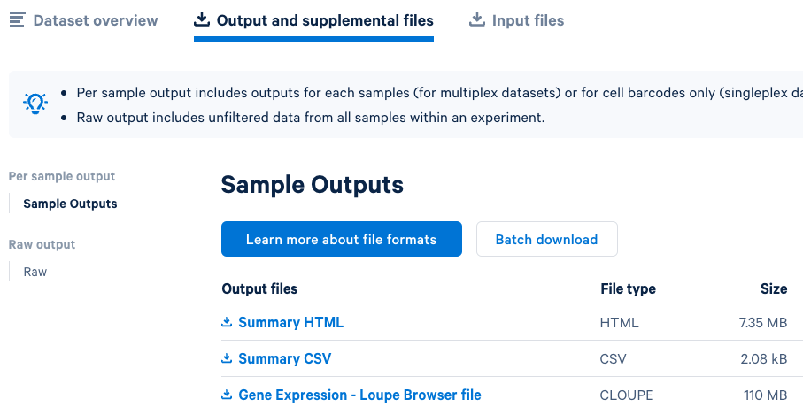

- Load in the data
  - Review various the groups i.e. clusters, annotation etc
  - Can you see the difference in how Kmeans and Graph-based clustering have performed?
  - Check the UMAP as well
  - Use split view to help check what cell types are most prevalent

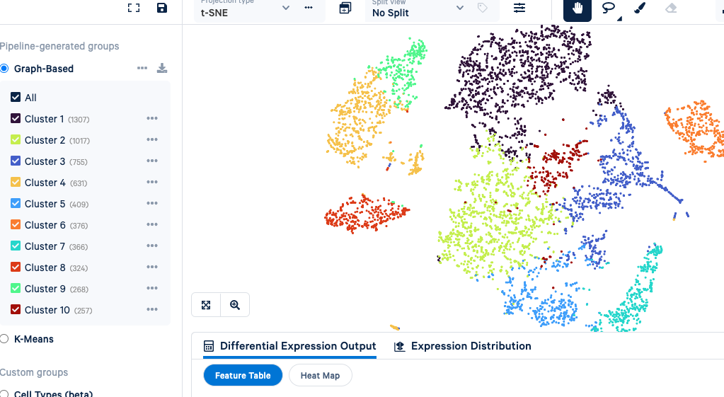

```r
# It looks like Kmeans cannot differentiate more than one group.
# Graph clustering gives better resolution.

#  T Cells, Monocytes and Macrophages seem the most prevalent
```

**Exercise 2** - **Differential Analysis**

- Markers
  - Cluster 6 sticks out as being the most distinct cluster. What genes are driving this?
  - Check how these markers look using the Feature tab and the violin plots
  - Cluster 3 has a strong hit - HBB. But there is an issue with this hit. What is it?

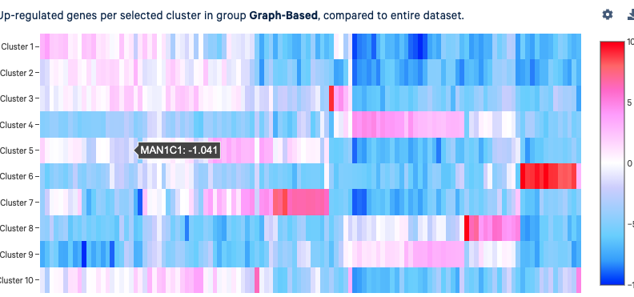

```r
# Looks like cluster 6 is associated with several Ig genes like IGHD and IGLC2

# Only one cell is driving HBB expression. This is the hemoglobin gene so maybe its a RBC. It is annotated as a hematopoeitic cell, but we can see there are a mixture of cell types annotated in this part of UMAP.
```

- Pairwise Comparison
  - Let’s compare Cluster 6 to Cluster 1
  - Review the top hits. Do they make sense?

```r
# Based on the annotation this is a comparison between T and B cells. The results should reflect this
# i.e. the top hits in cluster 6 are MS4A1 and BANK1 which are known markers of B cells
```

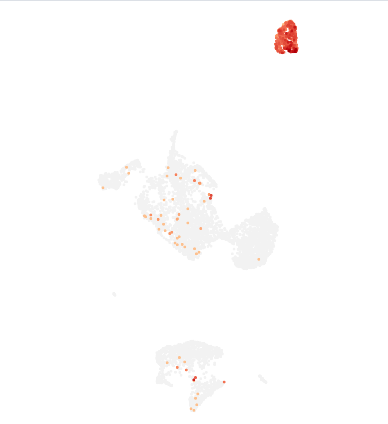

**Exercise 3** - **Features and Filters**

- Features
  - Double check some mitochondrial genes (they start with MT). Are there any problems there?
  - Check some known PBMC marker genes. You can manually try these or import the list from *LoupeBrowser/r_course/data/pbmc_markers.csv*:

CD3E: For T cells. CD79A: For B cells. NKG7: For NK cells. LY6C62: For monocytes or dendritic cells (DC). C1QA: For macrophage. FCER1A: For basophil. HBA1: For erythrocytes (RBC).

```r
# There is a mild asymmetry in MT so again something to keep an eye on, but it doesn't look too bad.
```

- Custom Groups
- There are two minor groups of cells that seem to have a mixed cluster annotation. Use freehand selection to create two groups. Look for Markers.

```r
# One cluster's top hits are TUBB1 and CAVIN2. These are platelet markers. But the annotation currently says hematopoeitic cell.

# The other cluster is a little more complex - with a mixture of identities including DC, erythrocytes and rare sub classes of T-cell.
```

- Filters
- Lets find some Regulatory T cells. These should have IL2RA and FOXP3.
- What cluster are they predominately found in?
- Does that cluster make sense? Go back and check its marker genes.

```r
# Seems like there is a streak of Treg cells.
# There is a hub in cluster 10
# Reviewing the cluster markers the top hit is RTKN2 which is associated with Treg cells.
```

- Reanalyze
  - When we made custom groups we identified a cluster with mixed identity. This as bottom right of the UMAP with cluster 10 and cluster 4 identities. Lets reanalyze but remove this cluster as it could be the product of doublets.